# Clasificación de Vinos según su calidad con Técnicas de Aprendizaje Automático

## Introducción

El dataset "Wine Quality" contiene dos conjuntos de datos relacionados con muestras de vino "Vinho Verde" en sus variantes tinto y blanco, provenientes del norte de Portugal. Cada vino fue evaluado sensorialmente por expertos, quienes le asignaron una puntuación de calidad en una escala de 0 a 10. Este dataset se presta para tareas de clasificación y regresión y es útil para analizar qué características influyen en la calidad del vino.

Nuestro objetivo es modelar la calidad del vino basándonos en las siguientes características fisicoquímicas:

- acidez fija
- acidez volátil,
- ácido cítrico
- azúcar residual
- cloruros
- dióxido de azufre
- densidad
- pH
- sulfatos
- contenido de alcohol.

[Link del dataset](https://archive.ics.uci.edu/dataset/186/wine+quality)

## Problema

Preguntas iniciales:

- ¿Qué variables influyen más en la calidad del vino?
- ¿Es posible predecir la calidad con un modelo de ML? ¿Qué modelo funciona mejor?
- ¿Cómo se diferencian los vinos de alta vs baja calidad en términos fisicoquímicos?
- ¿Existen patrones distintos entre vinos tintos y blancos?

## Importación y Limpieza

|  | fixed acidity | volatile acidity | citric acid | residual sugar | chlorides | free sulfur dioxide | total sulfur dioxide | density | pH | sulphates | alcohol | quality |
| --- | --- | --- | --- | --- | --- | --- | --- | --- | --- | --- | --- | --- |
| 0 | 7.4 | 0.70 | 0.00 | 1.9 | 0.076 | 11.0 | 34.0 | 0.9978 | 3.51 | 0.56 | 9.4 | 5 |
| 1 | 7.8 | 0.88 | 0.00 | 2.6 | 0.098 | 25.0 | 67.0 | 0.9968 | 3.20 | 0.68 | 9.8 | 5 |
| 2 | 7.8 | 0.76 | 0.04 | 2.3 | 0.092 | 15.0 | 54.0 | 0.9970 | 3.26 | 0.65 | 9.8 | 5 |
| 3 | 11.2 | 0.28 | 0.56 | 1.9 | 0.075 | 17.0 | 60.0 | 0.9980 | 3.16 | 0.58 | 9.8 | 6 |
| 4 | 7.4 | 0.70 | 0.00 | 1.9 | 0.076 | 11.0 | 34.0 | 0.9978 | 3.51 | 0.56 | 9.4 | 5 |

|  | fixed acidity | volatile acidity | citric acid | residual sugar | chlorides | free sulfur dioxide | total sulfur dioxide | density | pH | sulphates | alcohol | quality |
| --- | --- | --- | --- | --- | --- | --- | --- | --- | --- | --- | --- | --- |
| 0 | 7.0 | 0.27 | 0.36 | 20.7 | 0.045 | 45.0 | 170.0 | 1.0010 | 3.00 | 0.45 | 8.8 | 6 |
| 1 | 6.3 | 0.30 | 0.34 | 1.6 | 0.049 | 14.0 | 132.0 | 0.9940 | 3.30 | 0.49 | 9.5 | 6 |
| 2 | 8.1 | 0.28 | 0.40 | 6.9 | 0.050 | 30.0 | 97.0 | 0.9951 | 3.26 | 0.44 | 10.1 | 6 |
| 3 | 7.2 | 0.23 | 0.32 | 8.5 | 0.058 | 47.0 | 186.0 | 0.9956 | 3.19 | 0.40 | 9.9 | 6 |
| 4 | 7.2 | 0.23 | 0.32 | 8.5 | 0.058 | 47.0 | 186.0 | 0.9956 | 3.19 | 0.40 | 9.9 | 6 |

Por conveniencia uno ambos datasets en uno. Para eso, agrego primero en cada tabla una columna con el tipo de vino correspondiente.

## EDA

¿Cuántas filas y columnas tiene?

```
(6497, 14)
```

Tiene 6497 filas y 14 columnas

¿Hay valores faltantes en algunas columnas?

```
np.int64(0)
```

No tiene valores faltantes en ninguna de las variables

```
<class 'pandas.core.frame.DataFrame'>
RangeIndex: 6497 entries, 0 to 6496
Data columns (total 14 columns):
 #   Column                Non-Null Count  Dtype
---  ------                --------------  -----
 0   fixed acidity         6497 non-null   float64
 1   volatile acidity      6497 non-null   float64
 2   citric acid           6497 non-null   float64
 3   residual sugar        6497 non-null   float64
 4   chlorides             6497 non-null   float64
 5   free sulfur dioxide   6497 non-null   float64
 6   total sulfur dioxide  6497 non-null   float64
 7   density               6497 non-null   float64
 8   pH                    6497 non-null   float64
 9   sulphates             6497 non-null   float64
 10  alcohol               6497 non-null   float64
 11  quality               6497 non-null   int64
 12  tipo                  6497 non-null   object
 13  quality_c             6497 non-null   object
dtypes: float64(11), int64(1), object(2)
memory usage: 710.7+ KB
```

Casi todas las variables son numéricas continuas menos:

- **quality** (*numérica discreta*)
- **tipo** (*categórica*)
- **quality_c** (*binaria categórica*)

## Predicción

Queremos predecir la calidad del vino. Para eso vamos a hacer una matriz de correlación para definir qué variables usar de features/atributos.

Dropeamos las variables categóricas `quality_c` y `tipo` porque son variables de tipo objeto (string).

### Correlaciones

Para graficar la matriz de correlaciones entre variables le saco las columnas categóricas a la dataframe.

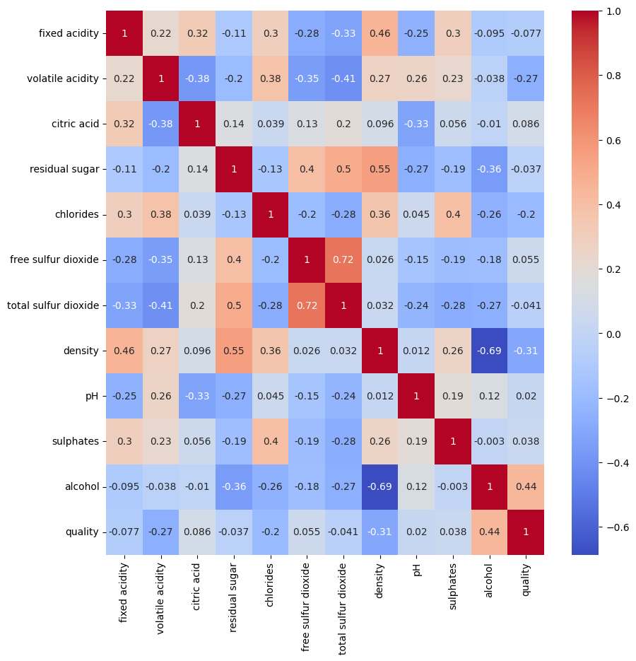

Elegimos las variables `alcohol` y `volatile acidity` porque tenían un error irreducible relativamente bajo a las otras variables con alta correlación a `quality`.

**¿Por qué usamos la variable "quality" y no "quality_c" para las correlaciones**

1. Usando `quality_c` en vez de `quality`, la correlación es posible pero: en el gráfico, esa variable mostrará correlaciones cercanas a 0 o ±1, dependiendo de cómo se codifique (“bueno”=1, “malo”=0). Puede interpretarse como una asociación direccional: por ejemplo, alcohol ↑ → mayor probabilidad de “bueno”.

**¿Por qué hacemos el drop "tipo"?**

2. Usando una variable tipo string como `tipo` No pueden correlacionarse numéricamente, corr() las ignora. No aparecerán en el gráfico. Para analizarlas habría que convertirlas a numéricas.

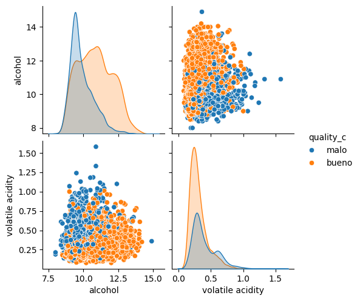

Estos gráficos muestran las relaciones entre las variables elegidas y sus distribuciones, separadas por clase.

Nos parece que estos dos atributos son buenos predictores (esto no quita que en un análisis posterior encontremos algun atributo mejor).

### 2. Resumen de lo realizado hasta ahora

El objetivo de este trabajo es analizar el dataset Wine Quality (“Vinho Verde”, tintos y blancos) para predecir la calidad del vino a partir de variables fisicoquímicas. Para lo cual unificamos ambos tipos de vino en un solo conjunto y los clasificamos en “bueno” o “malo”.  
Tras una exploración de datos, identificamos correlaciones relevantes, principalmente con el alcohol y la acidez volátil.  
Probamos tres modelos:

- Dummy
- Árbol de Decisión
- Random Forest.

Vamos a usar `'quality_c'` como target (binaria) y `'alcohol'` y `'volatile acidity'` como atributos

### 3. Benchmark: *Modelo Dummy* (modelo de base)

```
Desempeño del modelo clasificador Dummy (Accuracy): 0.534
Desempeño del modelo clasificador Dummy (Recall): 0.624
Desempeño del modelo clasificador Dummy (Precision): 0.634
```

### 4. Primer modelo: *Árbol de Decisión*

Vamos a escalar los atributos para que trabajen en el mismo rango (por buena práctica).

```
DecisionTreeClassifier(max_depth=4)
```

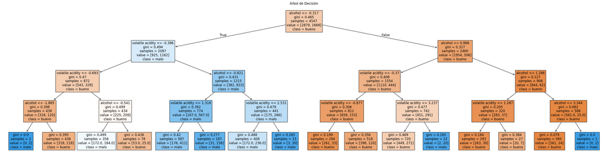

### 5. Evaluando el primer modelo

[figure not shown]

```
   • Profundidad real: 4
   • Número de nodos: 31
   • Número de hojas: 16
   • Exactitud (Accuracy): 0.744
   • Exhaustividad (Recall): 0.803
   • Precisión: 0.794
```

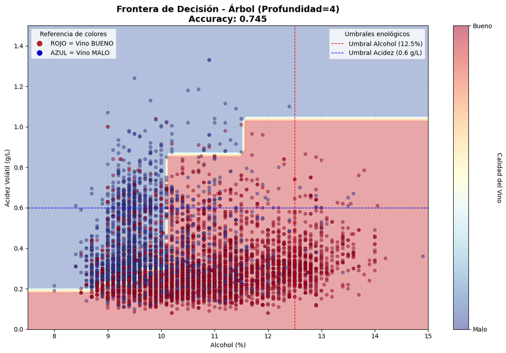

Validación cruzada - Árbol de Decisión

```
Exactitud promedio (entre 5 folds): 0.724
Desviación estandar de la exactitud: 0.012
```

### 6. Segundo modelo: *Random Forest*

Vamos a probar con un Random Forest. Pero antes, preprocesamos los atributos y el target

```
RandomForestClassifier(max_depth=10, random_state=42)
```

Gráfico de *un solo* arbol del modelo Random Forest

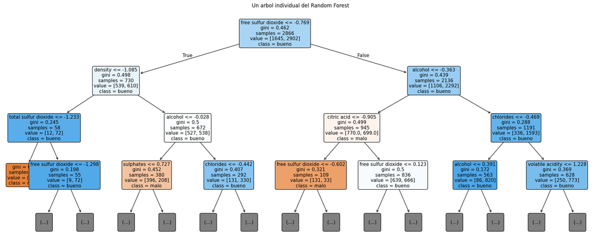

### 7. Evaluando el segundo modelo

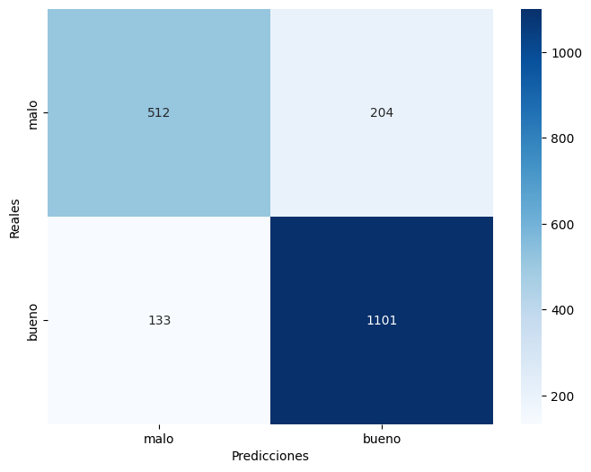

```
   • Profundidad máxima: 10
   • Máx número de nodos: 1329
   • Máx número de hojas: 665
   • Exactitud (Accuracy): 0.827
   • Exhaustividad (Recall): 0.892
   • Precisión: 0.844
```

Validación cruzada - Random Forest

```
Exactitud promedio (entre 5 folds): 0.807
Desviación estandar de la exactitud: 0.017
```

Importancia de los atributos (según el Random Forest)

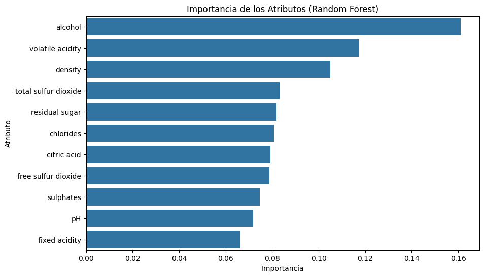

Top 3 atributos mas importantes seg:

- `alcohol`
- `volatile acidity`
- `density`

### 8. Comparación de modelos

#### Analítica

```
=== COMPARACIÓN DE MODELOS ===

Benchmark (Dummy Classifier):
  Accuracy: 0.534
  Recall: 0.624
  Precision: 0.634

Árbol de Decisión:
  Accuracy: 0.744
  Recall (Bueno): 0.803
  Precision (Bueno): 0.794

Random Forest:
  Accuracy: 0.827
  Recall (Bueno): 0.892
  Precision (Bueno): 0.844
```

#### Gráfica

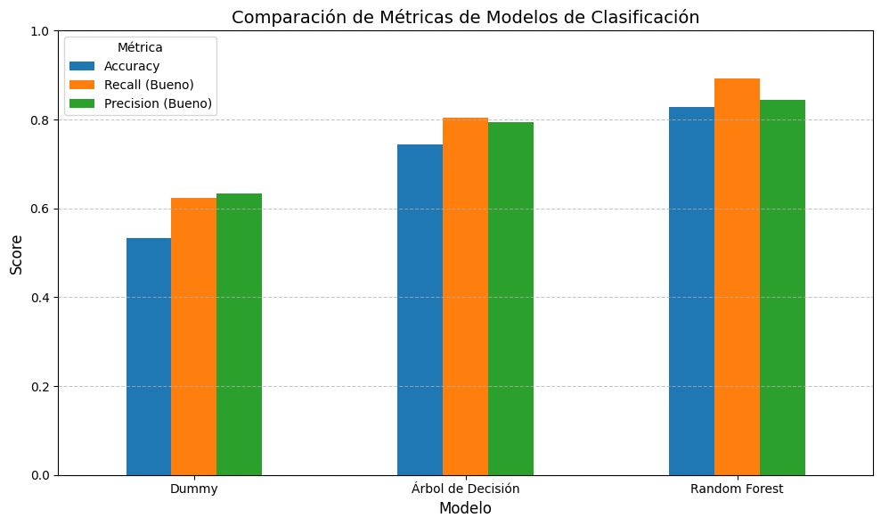

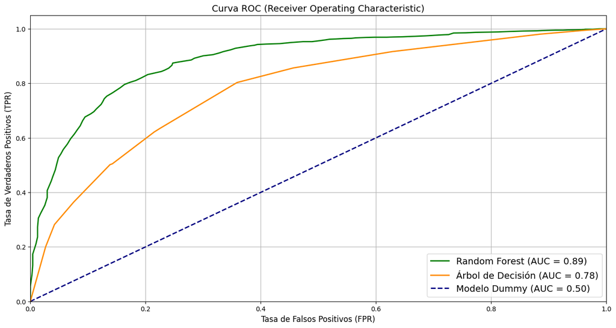